# Sign network prototype

Goal: treat the summer game signs and the street grid as one network. Intersections are nodes, street segments are edges, and each sign is its own node attached to the street network. This is the starting point for doing real routing (shortest paths, traveling-salesman style tours) along actual streets later.

This first pass just builds the combined network for ~50 signs around the densest cluster (the Old West Side) and draws a plain network plot – no basemap, no interactivity.

```python
import json

import matplotlib.pyplot as plt
import networkx as nx
import osmnx as ox
```

## Pick a cluster of signs

Load the full sign list and grab the 50 signs closest to the middle of the densest cluster. The 1.35 factor roughly corrects for longitude degrees being shorter than latitude degrees at Ann Arbor’s latitude, so “closest” is closest on the ground rather than in raw degrees.

```python
with open("docs/data/signs.json") as f:
    signs_geojson = json.load(f)

CLUSTER_CENTER = (-83.770, 42.285)  # lon, lat, Old West Side
N_SIGNS = 50

def ground_dist2(feature):
    lon, lat = feature["geometry"]["coordinates"]
    return (lon - CLUSTER_CENTER[0]) ** 2 + ((lat - CLUSTER_CENTER[1]) * 1.35) ** 2

signs = sorted(signs_geojson["features"], key=ground_dist2)[:N_SIGNS]
print(f"{len(signs_geojson['features'])} signs total, using {len(signs)}")
```

```
2486 signs total, using 50
```

## Download the street network

OpenStreetMap already stores streets in exactly the shape we want: intersections as nodes, street segments as edges with lengths in meters. `network_type="walk"` includes footpaths and ignores one-way restrictions, which is the right graph for sign hunting on foot.

```python
lons = [f["geometry"]["coordinates"][0] for f in signs]
lats = [f["geometry"]["coordinates"][1] for f in signs]
PAD = 0.002  # ~200m of margin around the signs

streets = ox.graph_from_bbox(
    (min(lons) - PAD, min(lats) - PAD, max(lons) + PAD, max(lats) + PAD),
    network_type="walk",
)
print(f"street graph: {len(streets.nodes)} intersections, {len(streets.edges)} edges")
```

```
street graph: 574 intersections, 1728 edges
```

## Combine into one network

Start from the street graph (collapsed to a simple undirected graph) and tag every existing node as an `intersection`. Then, instead of pinning each sign to its nearest intersection, split the sign’s nearest street edge at the point on the road closest to the sign: a new `snap` node goes in mid-block, the original edge becomes two street edges whose lengths split the block’s real length proportionally, and the sign connects to its snap node by a short `access` edge. Signs that sit mid-block are now mid-block in the network, so path distances along streets are exact. Signs are grouped by edge first so a block with several signs gets split at each of them in order.

```python
from collections import defaultdict

from shapely.geometry import LineString, Point

G = nx.Graph(streets.to_undirected())
nx.set_node_attributes(G, "intersection", "node_type")
nx.set_edge_attributes(G, "street", "edge_type")

def edge_line(u, v, k):
    """The street edge's geometry, falling back to a straight line."""
    data = streets.edges[u, v, k]
    if "geometry" in data:
        return data["geometry"]
    return LineString([
        (streets.nodes[u]["x"], streets.nodes[u]["y"]),
        (streets.nodes[v]["x"], streets.nodes[v]["y"]),
    ])

edge_hits = ox.distance.nearest_edges(streets, X=lons, Y=lats)
signs_on_edge = defaultdict(list)
for feature, (u, v, k) in zip(signs, edge_hits):
    signs_on_edge[tuple(sorted((u, v)))].append((u, v, k, feature))

for group in signs_on_edge.values():
    u, v, k, _ = group[0]  # one reference orientation for measuring positions
    line = edge_line(u, v, k)
    length_m = streets.edges[u, v, k]["length"]
    positions = sorted(
        ((line.project(Point(f["geometry"]["coordinates"]), normalized=True), f)
         for _, _, _, f in group),
        key=lambda pair: pair[0],
    )

    G.remove_edge(u, v)
    prev_node, prev_frac = u, 0.0
    for frac, feature in positions:
        lon, lat = feature["geometry"]["coordinates"]
        snap = line.interpolate(frac, normalized=True)
        sign_id = f"sign-{feature['properties']['id']}"
        snap_id = f"snap-{feature['properties']['id']}"
        G.add_node(snap_id, node_type="snap", x=snap.x, y=snap.y)
        G.add_edge(prev_node, snap_id, edge_type="street",
                   length=(frac - prev_frac) * length_m)
        G.add_node(sign_id, node_type="sign", x=lon, y=lat,
                   addr=feature["properties"]["addr"])
        G.add_edge(sign_id, snap_id, edge_type="access",
                   length=ox.distance.great_circle(lat, lon, snap.y, snap.x))
        prev_node, prev_frac = snap_id, frac
    G.add_edge(prev_node, v, edge_type="street",
               length=(1.0 - prev_frac) * length_m)

counts = nx.get_node_attributes(G, "node_type")
print(f"combined graph: {len(G.nodes)} nodes, {len(G.edges)} edges")
print(f"  {sum(t == 'intersection' for t in counts.values())} intersections")
print(f"  {sum(t == 'snap' for t in counts.values())} snap points")
print(f"  {sum(t == 'sign' for t in counts.values())} signs")
```

```
combined graph: 674 nodes, 961 edges
  574 intersections
  50 snap points
  50 signs
```

## Plot the network

Plain networkx/matplotlib plot. Node positions are just the raw coordinates used as layout positions – no projection or basemap. Where a street looks like two or three parallel lines, that is OSM mapping the sidewalks on each side as their own ways; the walk network keeps them.

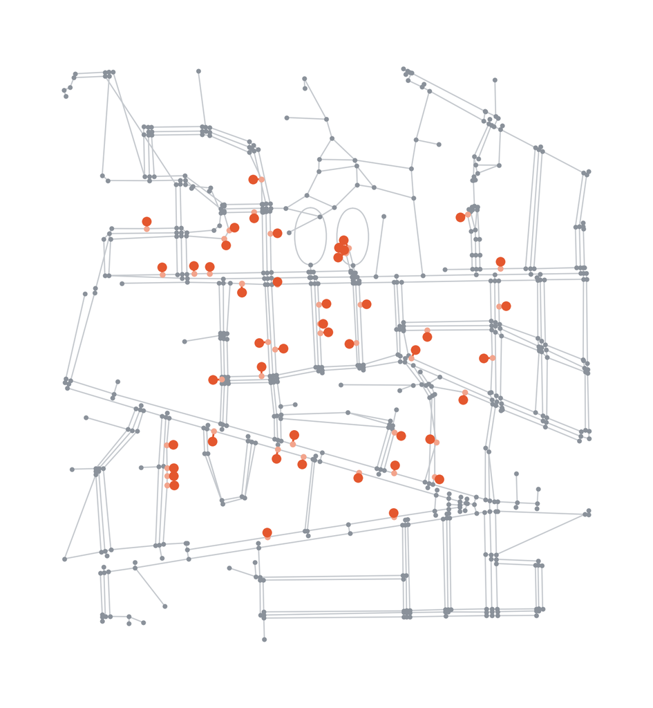

Figure 1: Street network (gray) with signs (red) attached to snap nodes (small orange) splitting their nearest street edge.

```python
pos = {n: (d["x"], d["y"]) for n, d in G.nodes(data=True)}
intersections = [n for n, d in G.nodes(data=True) if d["node_type"] == "intersection"]
snap_nodes = [n for n, d in G.nodes(data=True) if d["node_type"] == "snap"]
sign_nodes = [n for n, d in G.nodes(data=True) if d["node_type"] == "sign"]
street_edges = [(u, v) for u, v, d in G.edges(data=True) if d["edge_type"] == "street"]
access_edges = [(u, v) for u, v, d in G.edges(data=True) if d["edge_type"] == "access"]

fig, ax = plt.subplots(figsize=(10, 10))
nx.draw_networkx_edges(G, pos, edgelist=street_edges, edge_color="#c5c9ce", width=1, ax=ax)
nx.draw_networkx_edges(G, pos, edgelist=access_edges, edge_color="#e4572e", width=1.5, style="dashed", ax=ax)
nx.draw_networkx_nodes(G, pos, nodelist=intersections, node_size=8, node_color="#8a919a", ax=ax)
nx.draw_networkx_nodes(G, pos, nodelist=snap_nodes, node_size=14, node_color="#f2a48c", ax=ax)
nx.draw_networkx_nodes(G, pos, nodelist=sign_nodes, node_size=45, node_color="#e4572e", ax=ax)
ax.set_aspect(1.35)
ax.axis("off")
plt.show()
```

Every edge now carries a `length` in meters, including the split block segments and the sign access edges, so the next steps are direct: compute a sign-to-sign shortest-path distance matrix along the streets, then run a TSP-style solver over it for optimal collection routes.